EdMOOC-Survival: Home - Typical Curves - Analysis

# EdMOOC-Survival: Basic Analysis

This report looks at the patterns evident in the student last-access time data without considering any explanation according to learner attributes.

**Although the official course start date was January 28, 2013, the de-facto start date (based on a burst of student access) was one day earlier. Hence, “day 0” is January 27, 2013.

*This may be a consequence of time-zone differences, with the coursera platform being located in a zone that is 8 hours behind Edinburgh. The recorded time-stamps are observed to be in “platform time”, rather than in the time-zone of either the course provider or the learner. The absence of learner-local time presents a minor limitation on analysis, although it could be partially-corrected by looking up the country of access based on IP addresses. This is not done, so the concept of “day” remains slightly fuzzy.*

## The Raw Pattern of Last-Access

The following plots show the fall-off of students (system users with access_group_id=4) according to their last access time. This does not include students who actively withdrew, for whom last access data is deleted. They are presented at the start because of their logical part in a process of enquiry, although they are not particularly revealing; skip to the end of this section for a summary, or onto the next section to see how segmenting the population enables easier interpretation.

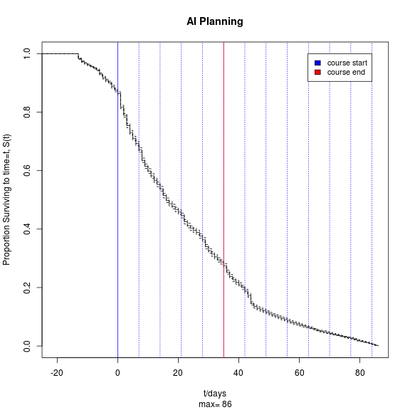

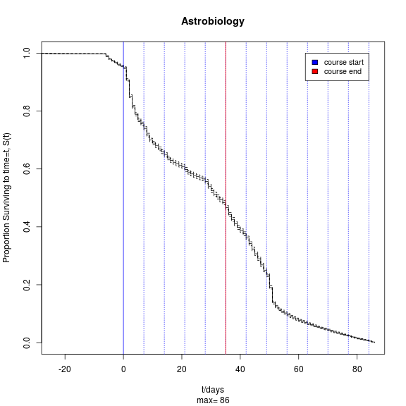

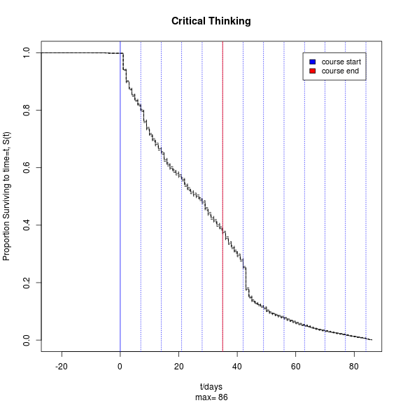

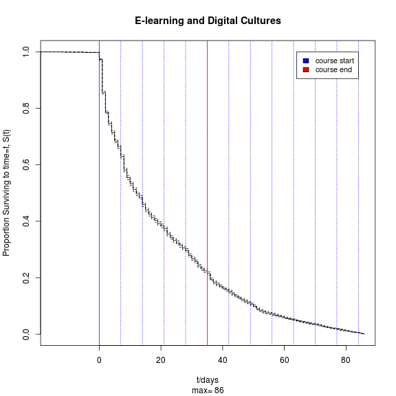

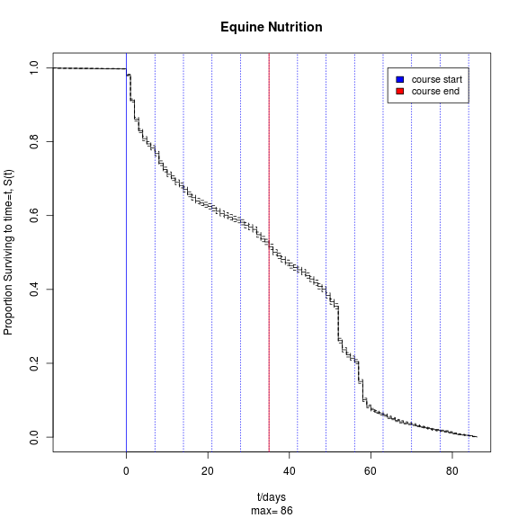

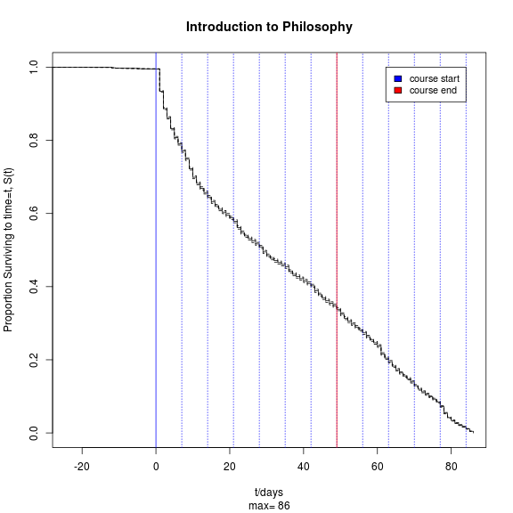

These plots all show the full range of last access times from 28 days prior to course start, up to the last registered access time.

These curves include both students who are awarded an achievement status and those who do not. This means that they include students whose last access time is related to their completion of the required tasks.

## Segmenting the Population

The concluding remarks in the previous section indicate that a better understanding will be gained if the two groups - those who gain an achievement status and those who do not - are treated separately.

The following treatment will also separate out students whose last-access time appears at either end of the timescale. The principal analysis will concentrate on students whose last-access time is not before the course start date and is also no later than 4 weeks after the end of the course (“end window”). Students whose last access time is after this end window are referred to as being “censored”; their presence is accounted for in the analysis as a block of individuals who are known to be present at the end but whose actual last access time is not used.

This means that the clearly-different process in place before the course start, and the possible consequences of the “day 86” cutoff are excluded. The pre-course-start attrition may be of interest in understanding the relationship between MOOC participants and the course offering/design but the cutoff introduces only an incidental artefact.

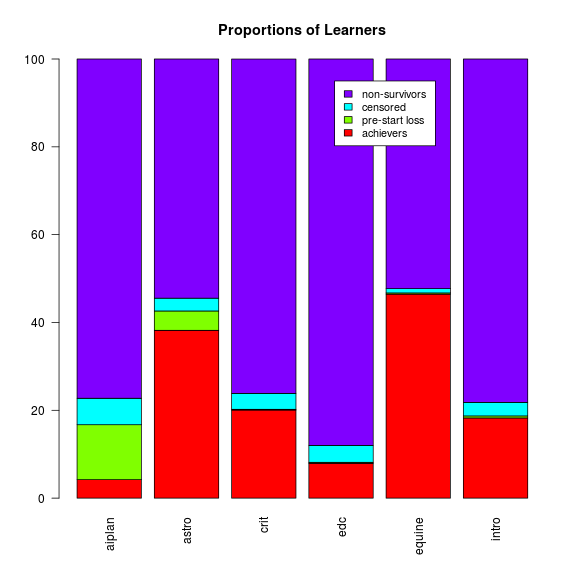

## Inspecting the Non-Achievers

This section is concerned with students whose last-access time is not before the course start date and is also no later than 4 weeks after the end of the course, and who were not awarded a Statement of Achievement.

Two plots are shown for each course. The first shows the fall-off in the above-specified group, i.e. the group's surivival function. A Kaplan-Meier Estimator is used to determine the likely survival curve for the observed data; the aparrent fuzziness of the curves is due to 95% confidence limits, which may be seen if the plots are viewed closely. The second shows the cumulative hazard function, for which a straight line indicates that the fall-off is exponential, i.e. that the proportion of loss in unit time remains the same at differing times.

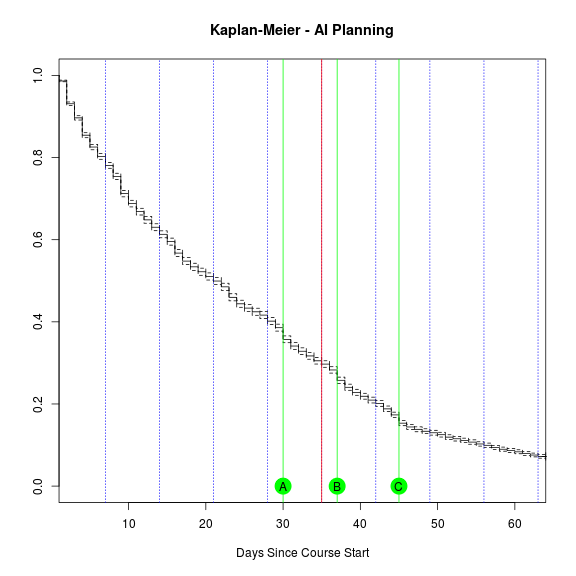

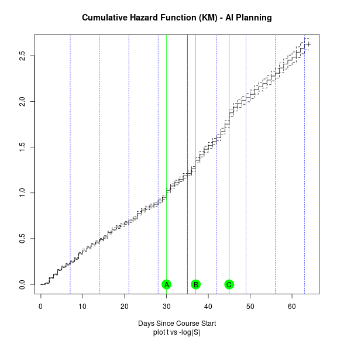

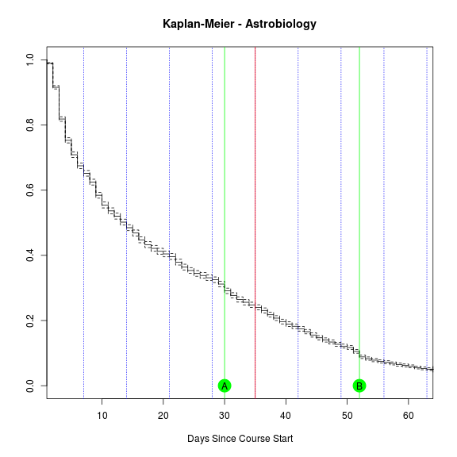

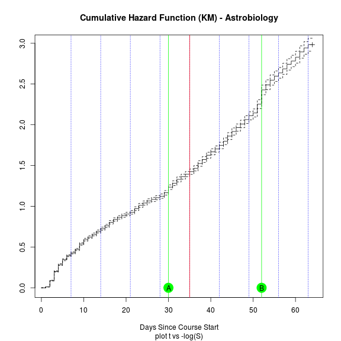

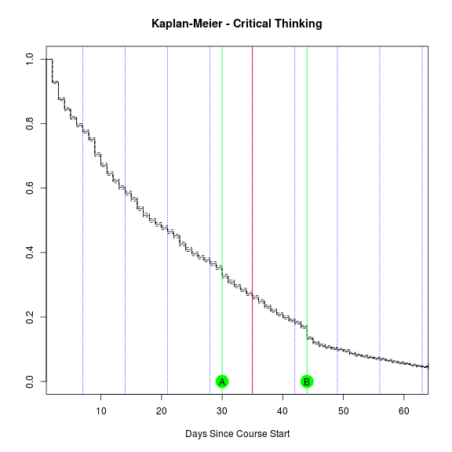

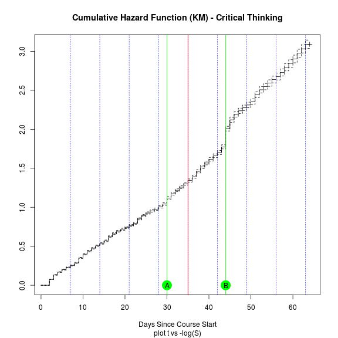

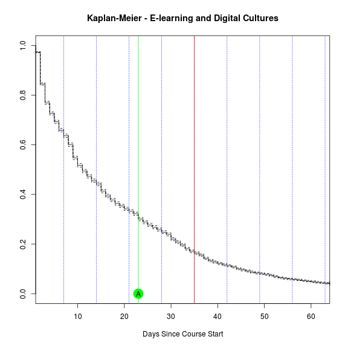

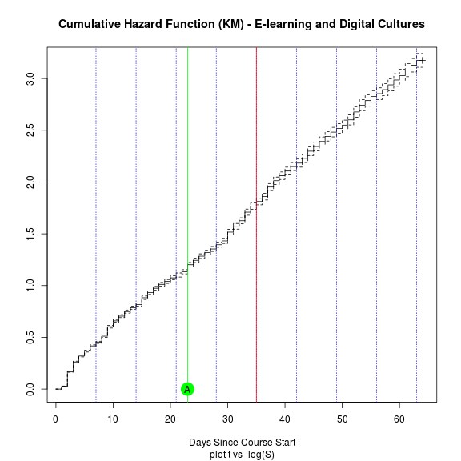

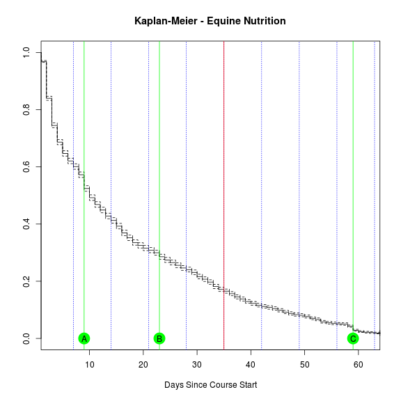

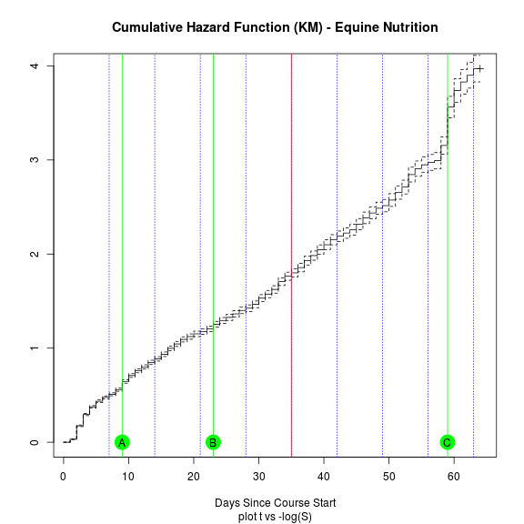

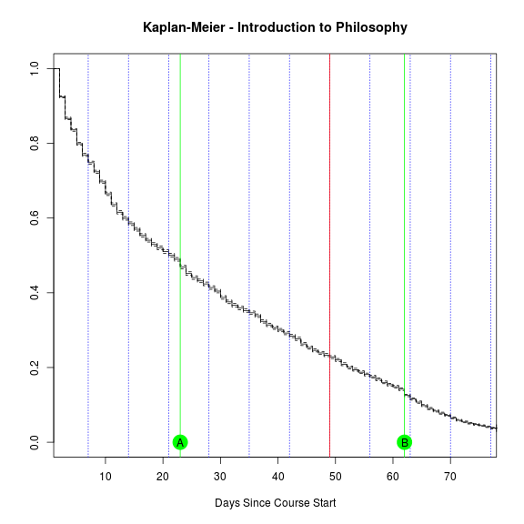

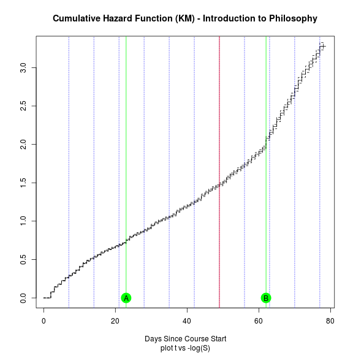

The removal of achievers has clearly simplified the shape of the curves, hence simplified attempts to explain the processes of attrition. Some general observations may be made from the survival curves:

- The survival curves for all course are qualitatively similar, with a generally smooth and continuous decay.
- Several survival curves show small but regular cycles where there seems to be a slightly larger fall-off on certain days of the week. This may be due to changes in log-in frequency on certain days of the week rather than being a consequence of a periodic event that is actually causing drop-out. Weekly cycles of activity are known to occur in MOOCs but the data is not available for the current cases. Variation between courses, with some having more prominent weekly “blips” than others, may be partially due to differing balance of participation across different time-zones.

The cumulative hazard (CH) curves permit a more detailed appreciation of the fall-off:

A purely exponential decay throughout the time-period may be considered to be a statistical baseline; it represents the case where drop-out is uniform across time and across the population. This is not what would be expected for real-world courses; courses are non-uniform in time by design, and learners are non-uniform by nature of prior knowledge, educational level, motivation, culturally-based expectations, etc. Variation in learner characterists would lead to smooth curves with a shape other than exponential. Changes in the shape at different points in time, as observed, indicates either a one-off event or a transition in character of the course. It is not easy to decide whether such a course change would have effect on survival of specific groups of students or across all groups.

### Fitting Parametric Survival Functions

In order to assess whether these survival curves for non-achievers do conform to an exponential decay a statistical fit was undertaken using the Survival package for R (specifically survreg). The exponential is the simplest parametric formula, with a single fittable parameter, and is compared against two two-parameter formulae: Weibull and Log-Logistic. Some background on these three forms, including plots with parameters that are representative of the MOOC data is available on the Typical Curves page.

#### AI Planning

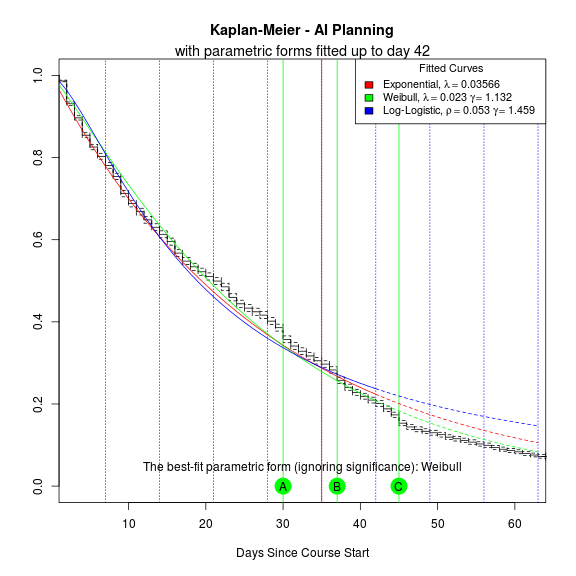

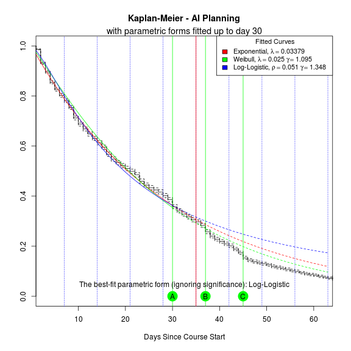

The solid lines for the fitted curves indicate the date range for which the fit was undertaken and the dashed lines project the same curve to later times.

#### Astrobiology

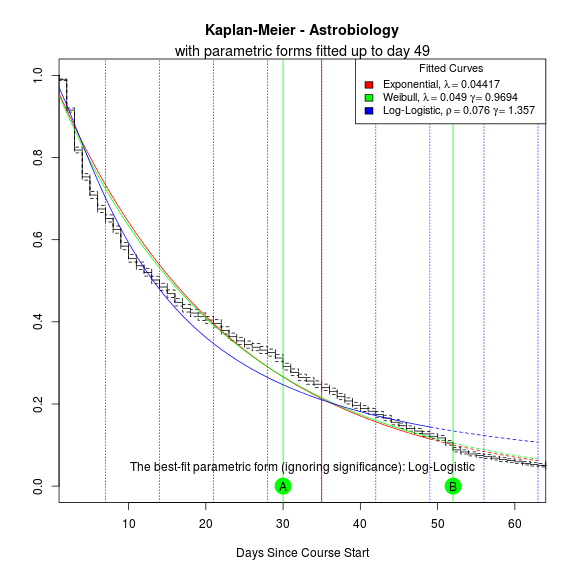

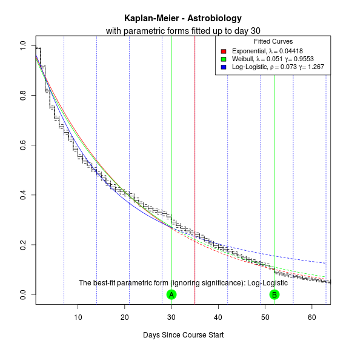

#### Critical Thinking

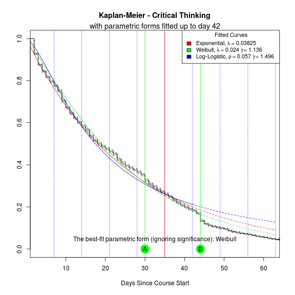

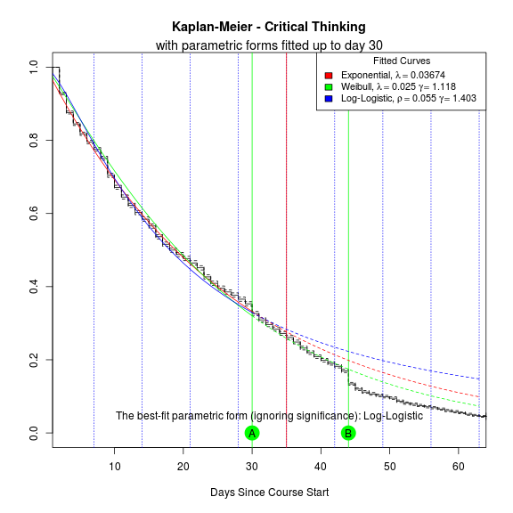

#### E-learning and Digital Cultures

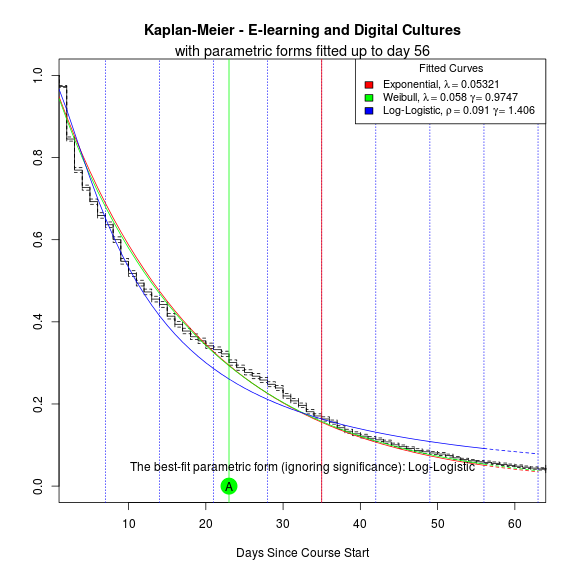

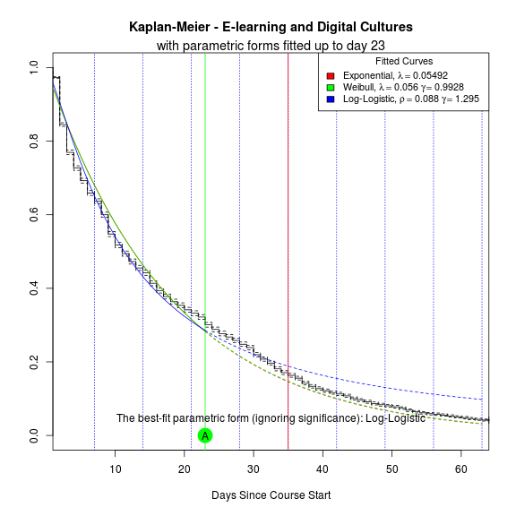

#### Equine Nutririon

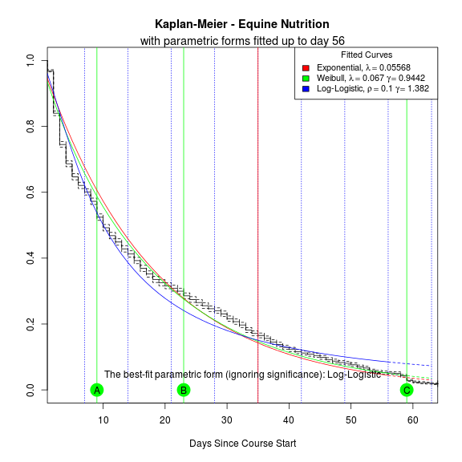

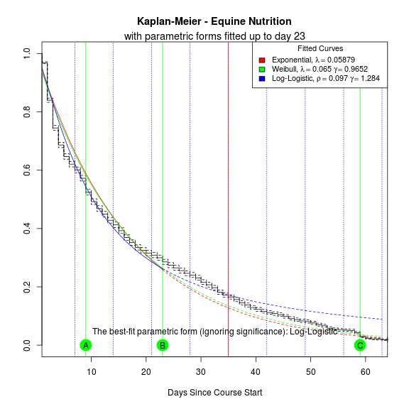

#### Introduction to Philosophy

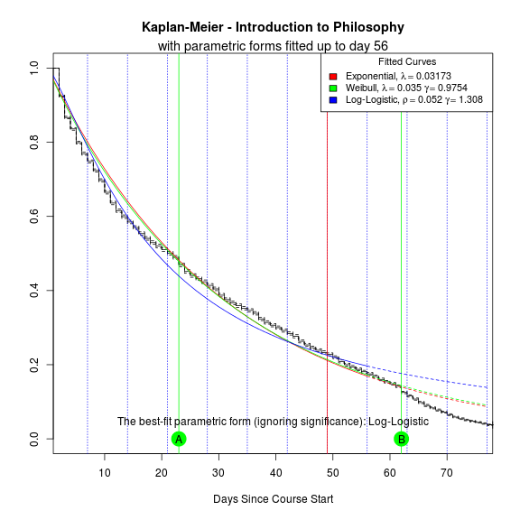

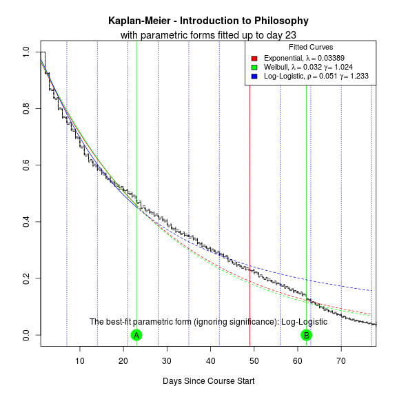